# SFML Project

### The coefficient of determination (R2 score)

The R2 value indicates how well the regression predictions match the actual data points. </br> The following formula is used to compute the value of R2: $$ R^{2} = 1 - \frac{\sum{(y_i - \hat{y_i})^{2}}}{\sum{(y_i - \bar{y_i})^{2}}} $$ where i is the projected value of yi and is the mean of the observed data, computed as $$ \bar{y} = \sum{y_i} $$ R2 has a range of values ranging from 0 to 1. The regression predictions exactly fit the data if the value is 1.

```python
mae = mean_absolute_error(Y_test, y_prediction_lin)
mse = mean_squared_error(Y_test, y_prediction_lin)
r2 = r2_score(Y_test, y_prediction_lin)

print('MAE is {}'.format(mae))
print('MSE is {}'.format(mse))
print('R2 score is {}'.format(r2))
```

```
MAE is 35.9082260163343
MSE is 2111.4669534348354
R2 score is 0.7592140564975793
```

Figure Radio advertisement cost and sales for linear regression.

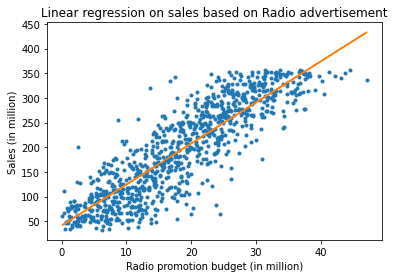

```python
a1 = X_test['Radio'].tolist()
a2 = Y_test['Sales'].tolist()
Radio = [float(x) for x in a1]
Sales = [float(x) for x in a2]
m, b = np.polyfit(Radio, Sales, 1)
plt.plot(Radio, Sales, '.')
Radio_Y = [x * m + b for x in Radio]
plt.plot(Radio, Radio_Y)
plt.title("Linear regression on sales based on Radio advertisement")
plt.xlabel('Radio promotion budget (in million)')
plt.ylabel('Sales (in million)')
plt.show()
```

Moreover, now we repeat it for polynomial linear regression.

```python
lin_reg = LinearRegression()
lin_reg.fit(X_train, Y_train)
poly_reg = PolynomialFeatures(degree=5)
X_poly = poly_reg.fit_transform(X_train)
poly_reg.fit(X_poly, Y_train)
lin_reg2 = LinearRegression()
lin_reg2.fit(X_poly, Y_train)
y_prediction_poly = lin_reg2.predict(poly_reg.fit_transform(X_test))
```

And you can see the evaluation of it here

```python
mae = mean_absolute_error(Y_test, y_prediction_poly)
mse = mean_squared_error(Y_test, y_prediction_poly)
r2 = r2_score(Y_test, y_prediction_poly)

print('MAE is {}'.format(mae))
print('MSE is {}'.format(mse))
print('R2 score is {}'.format(r2))
```

```
MAE is 34.32115945730862
MSE is 1985.2979983086886
R2 score is 0.7736020206811265
```

Figure Radio advertisement cost and sales for polynomial linear regression.

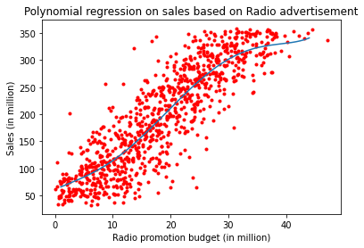

```python
a1 = X_test['Radio'].tolist()
a2 = Y_test['Sales'].tolist()
Radio = [float(x) for x in a1]
Sales = [float(x) for x in a2]
myModel = np.poly1d(np.polyfit(Radio, Sales, 5))
myLine = np.linspace(1, 44, 360)
plt.plot(Radio, Sales, '.', color="red")
plt.plot(myLine, myModel(myLine))
plt.title("Polynomial regression on sales based on Radio advertisement")
plt.xlabel('Radio promotion budget (in million)')
plt.ylabel('Sales (in million)')
plt.show()
```

And then we can compare these results:

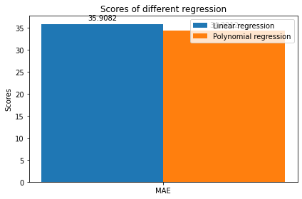

```python
labels = ['MAE']

linear = [
    mean_absolute_error(Y_test, y_prediction_lin),
]
polynomial = [
    mean_absolute_error(Y_test, y_prediction_poly),
]

x = np.arange(len(labels))  # the label locations
width = 0.15  # the width of the bars

fig, ax = plt.subplots()
rects1 = ax.bar(x - width/2, linear, width, label='Linear regression')
rects2 = ax.bar(x + width/2, polynomial, width, label='Polynomial regression')

# Add some text for labels, title and custom x-axis tick labels, etc.
ax.set_ylabel('Scores')
ax.set_title('Scores of different regression')
ax.set_xticks(x, labels)
ax.legend()

ax.bar_label(rects1, padding=3)
ax.bar_label(rects2, padding=3)

fig.tight_layout()

plt.show()
```

So here we have the results. As you can see, MAE in polynomial regression is 34.32115945730862. It is 35.9082260163343 in the linear regression, so we can see that the results for polynomial regression are slightly better, and the reason that there is not much difference is because of the form of the data we have. Nevertheless, it is interesting that the improvement is visible even in such a linear dataset.

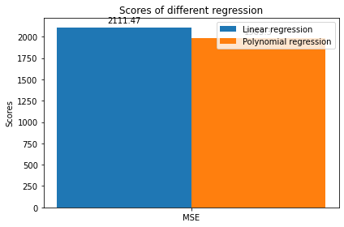

```python
labels = ['MSE']

linear = [
    mean_squared_error(Y_test, y_prediction_lin),
]
polynomial = [
    mean_squared_error(Y_test, y_prediction_poly),
]

x = np.arange(len(labels))  # the label locations
width = 0.15  # the width of the bars

fig, ax = plt.subplots()
rects1 = ax.bar(x - width/2, linear, width, label='Linear regression')
rects2 = ax.bar(x + width/2, polynomial, width, label='Polynomial regression')

# Add some text for labels, title and custom x-axis tick labels, etc.
ax.set_ylabel('Scores')
ax.set_title('Scores of different regression')
ax.set_xticks(x, labels)
ax.legend()

ax.bar_label(rects1, padding=3)
ax.bar_label(rects2, padding=3)

fig.tight_layout()

plt.show()
```

So here we have the results. As you can see, MSE in polynomial regression is 1985.2979983086886. It is 2111.4669534348354 in the linear regression, so we can see that the results for polynomial regression are better, and the reason that there is not much difference is because of the form of the data we have. However, it is interesting that the improvement is visible even in such a linear dataset.

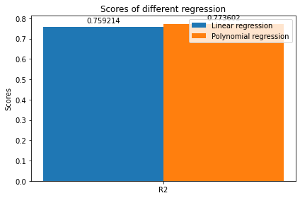

```python
labels = ['R2']

linear = [
    r2_score(Y_test, y_prediction_lin),
]
polynomial = [
    r2_score(Y_test, y_prediction_poly),
]

x = np.arange(len(labels))  # the label locations
width = 0.15  # the width of the bars

fig, ax = plt.subplots()
rects1 = ax.bar(x - width/2, linear, width, label='Linear regression')
rects2 = ax.bar(x + width/2, polynomial, width, label='Polynomial regression')

# Add some text for labels, title and custom x-axis tick labels, etc.
ax.set_ylabel('Scores')
ax.set_title('Scores of different regression')
ax.set_xticks(x, labels)
ax.legend()

ax.bar_label(rects1, padding=3)
ax.bar_label(rects2, padding=3)

fig.tight_layout()

plt.show()
```

So here we have the results. As you can see, R2 in polynomial regression is 0.7736020206811265, and it is 0.7592140564975793 in the linear regression, so we can see that the results for polynomial regression are better and it is a better fit. The reason that there is not much difference is because of the form of the data we have. However, it is interesting that the improvement is visible even in such a linear dataset.</br> So overall, the polynomial regression is better than the linear regression.